# Corona Analysis

Samuel Knapp - samuel.k@gmx.de

# Download data

Data were downloaded from the github repository of the Johns Hopkins University. These are the same data, from which the famous GIS world map is created. See: https://github.com/CSSEGISandData/COVID-19

Newest date

```
## [1] "20-04-02"
```

# Selected countries

The following countries were set to be included: Germany, Switzerland, Hong Kong, Singapore. Additionally, 16 countries with the highest number of confirmed cases were added.

# Actual numbers

The number of confirmed and death cases for each day.

Hong Kong and Singapore both show two phases of linear growth. South Korea first had an exponential growth and then turned into linear growth.

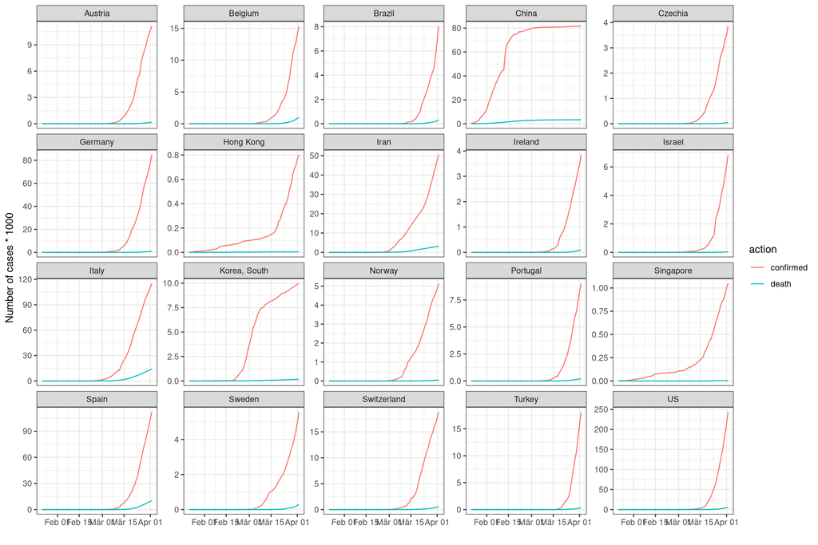

# Ratio of death to infected

Simply the ratio of reported deaths divided by number of confirmed cases for each day. Interesting to see that this ratio increases i most countries. A particularly sharp increase can be observed for countries that start to struggle: Italy, Spain, and Belgium. However, this calculation is probably too simple, as it does not take account of recovered cases.

Note, that in Italy last points are not in plot anymore.

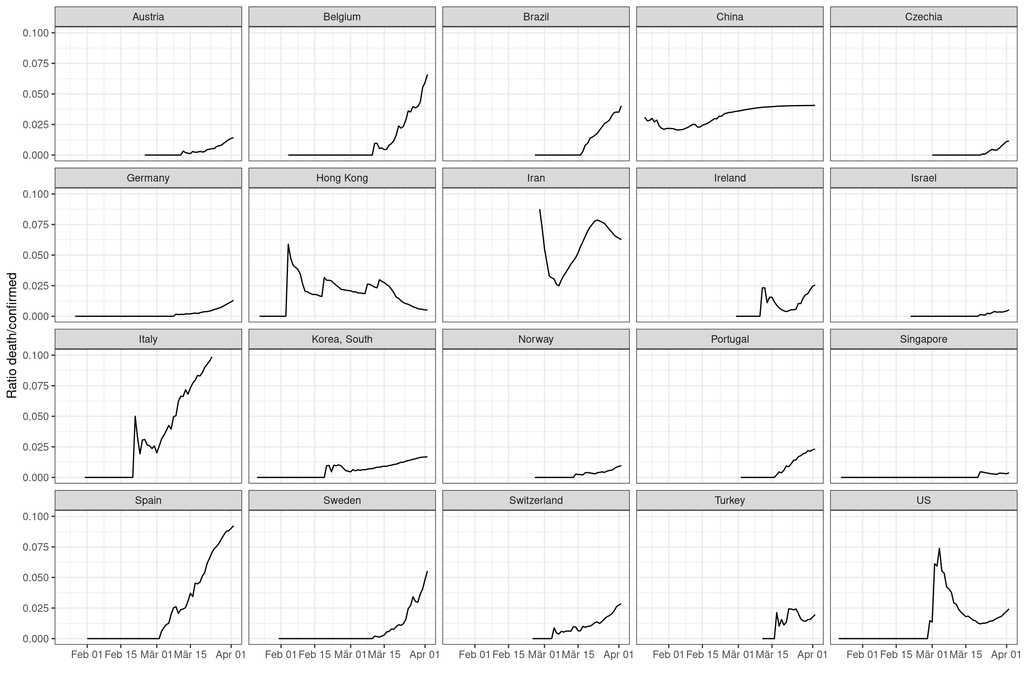

# New cases

Simply the daily increase of confirmed cases.

## Relative increase per day

A relative increase of e.g. b=1.2 indicates that the number of confirmed cases increases by 20% in one day, e.g. from 1000 to 1200. This number (b) can be related to the number of days needed for doubling the number of confirmed cases by $b^x=2$, with $x$ as the number of days. The following shows the relation of $b$ to $x$. The sometimes mentioned aim of a doubling time of ten days thus corresponds to $b\approx1.07$.

| b | NumberOfDays |
| --- | --- |
| 1.05 | 14.21 |
| 1.10 | 7.27 |
| 1.15 | 4.96 |
| 1.20 | 3.80 |
| 1.25 | 3.11 |
| 1.30 | 2.64 |
| 1.35 | 2.31 |
| 1.40 | 2.06 |

While the relative increase was at around $b\approx1.3$ to $b\approx1.4$ (meaning a doubling of confirmed cases every 2 to 2.6 days), this rate has dropped to around $b\approx1.1$ in most countries. This might be most probably due to the imposed measures.

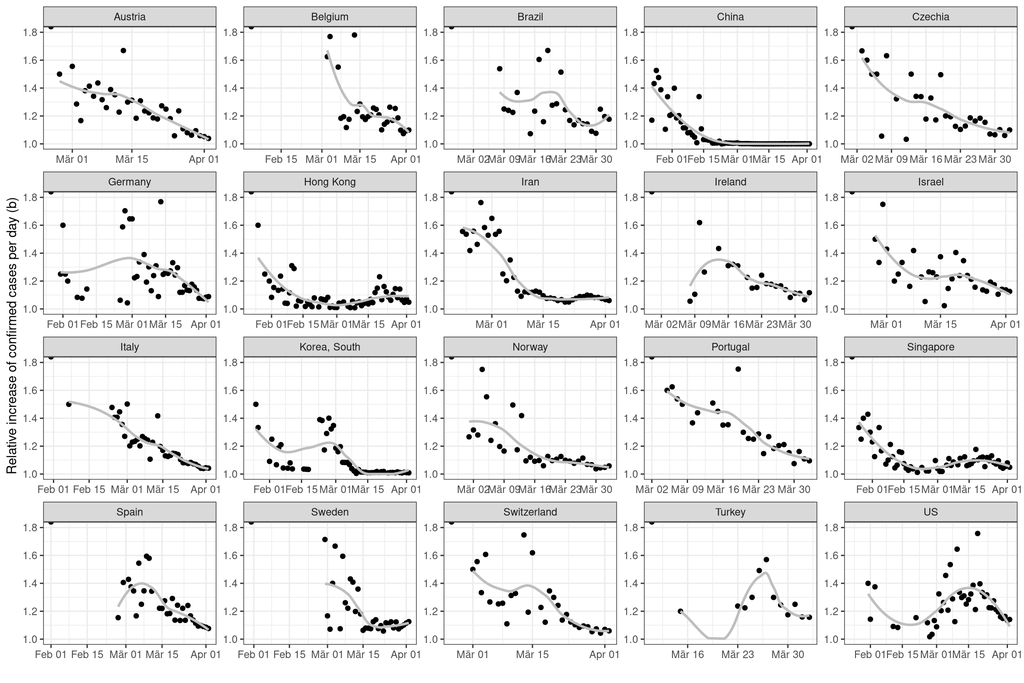

## Absolute increase

### Absolute numbers

For the capacity of the health systems, it is more important to look at the absolute numbers of new confirmed cases. The aim should be to get a constant number of new cases at a niveau which can be handled by the health system.

Austria and Switzerland have managed to drop the increase to a constant level. In many other countries (also Germany) the daily increases are still increasing.

In South Korea it can be nicely see how the exponential growth was lowered to a linear growth. This could/should be the aim…

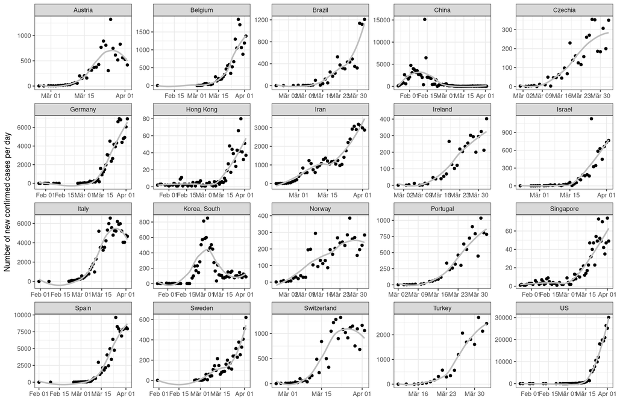

### As number per 100 thousand inhabitants

Relating the absolute number of new cases to the total population per country. All in similar range, but still different. Not sure about the interpretation.

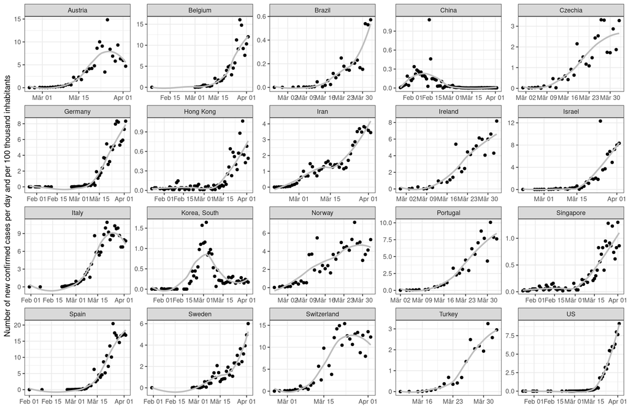

# Fit exponential function

An exponential function ($y=a*b^x$) is fit using only the data from when there were more than 50 confirmed cases per country. While the exponential used to fit very well up to around 1 or 2 weeks ago, they don’t fit that well anymore (fortunately!). But in some countries (US), the exponential function still fits very well.

It would be nice now to fit some kind of logistic growth function to determine if and when there was a turning point.

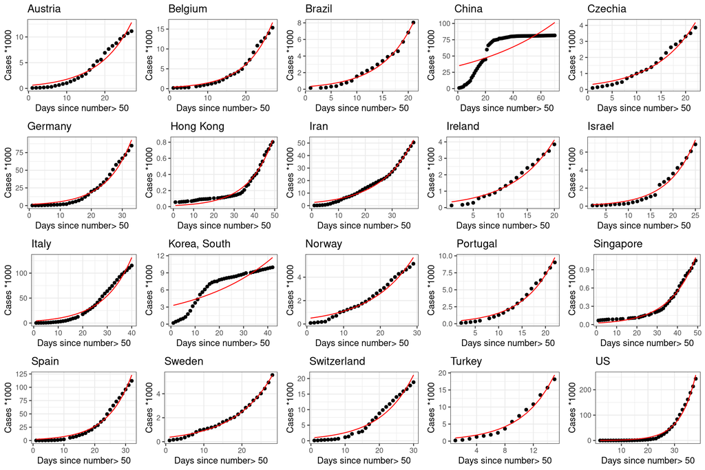

# Percentage of population

Number of confirmed cases (most recent day) divided by the total population.

| country | RatioPercent |
| --- | --- |
| Holy See | 0.876 |
| San Marino | 0.730 |
| Andorra | 0.552 |
| Luxembourg | 0.405 |
| Iceland | 0.362 |
| Spain | 0.238 |
| Switzerland | 0.219 |
| Liechtenstein | 0.194 |
| Italy | 0.191 |
| Monaco | 0.157 |
| Belgium | 0.133 |
| Austria | 0.125 |
| Germany | 0.102 |
| Norway | 0.096 |
| Portugal | 0.088 |
| Ireland | 0.078 |
| Israel | 0.075 |
| US | 0.074 |
| Estonia | 0.065 |
| Iran | 0.061 |
| Sweden | 0.054 |
| Slovenia | 0.043 |
| Bahrain | 0.042 |
| Cyprus | 0.041 |
| Malta | 0.040 |
| Czechia | 0.036 |
| Qatar | 0.035 |
| Panama | 0.031 |
| Brunei | 0.030 |
| Finland | 0.027 |
| Croatia | 0.025 |
| Latvia | 0.024 |
| Lithuania | 0.023 |
| Montenegro | 0.023 |
| Armenia | 0.022 |
| Turkey | 0.022 |
| Korea, South | 0.019 |
| Moldova | 0.019 |
| North Macedonia | 0.018 |
| Singapore | 0.018 |
| Ecuador | 0.018 |
| Chile | 0.018 |
| Saint Kitts and Nevis | 0.017 |
| Serbia | 0.017 |
| Dominica | 0.017 |
| Bosnia and Herzegovina | 0.016 |
| Barbados | 0.016 |
| New Zealand | 0.016 |
| Greece | 0.014 |
| Romania | 0.014 |